# Breast Cancer Wisconsin - 분류분석

박혜연

2023-12-11

#### 개요: 이 과제의 주요 목표는 Breast Cancer Wisconsin 데이터셋을 활용하여 유방암 양성과 음성을 분류하는 분류 분석 모델을 개발을 하는 것이다. 데이터를 훈련 및 테스트 셋으로 분할하고 로지스틱 회귀분석, 의사결정나무, 앙상블 기법, SVM 등을 활용하여 각 모델의 성능을 비교해볼 것이다.

[wisconsin dataset출처](https://archive.ics.uci.edu/dataset/17/breast+cancer+wisconsin+diagnostic) Breast Cancer Wisconsin 데이터셋은 종양의 특성에 관한 다양한 특징(세포 크기, 모양 등)과  
양성(1) 또는 음성(0) 유방암 여부를 포함하고 있다.

```r
df <- read.csv("wisconsin.csv")
summary(df)
```

```
##        id             diagnosis          radius_mean      texture_mean
##  Min.   :     8670   Length:569         Min.   : 6.981   Min.   : 9.71
##  1st Qu.:   869218   Class :character   1st Qu.:11.700   1st Qu.:16.17
##  Median :   906024   Mode  :character   Median :13.370   Median :18.84
##  Mean   : 30371831                      Mean   :14.127   Mean   :19.29
##  3rd Qu.:  8813129                      3rd Qu.:15.780   3rd Qu.:21.80
##  Max.   :911320502                      Max.   :28.110   Max.   :39.28
##  perimeter_mean     area_mean      smoothness_mean   compactness_mean
##  Min.   : 43.79   Min.   : 143.5   Min.   :0.05263   Min.   :0.01938
##  1st Qu.: 75.17   1st Qu.: 420.3   1st Qu.:0.08637   1st Qu.:0.06492
##  Median : 86.24   Median : 551.1   Median :0.09587   Median :0.09263
##  Mean   : 91.97   Mean   : 654.9   Mean   :0.09636   Mean   :0.10434
##  3rd Qu.:104.10   3rd Qu.: 782.7   3rd Qu.:0.10530   3rd Qu.:0.13040
##  Max.   :188.50   Max.   :2501.0   Max.   :0.16340   Max.   :0.34540
##  concavity_mean    concave.points_mean symmetry_mean    fractal_dimension_mean
##  Min.   :0.00000   Min.   :0.00000     Min.   :0.1060   Min.   :0.04996
##  1st Qu.:0.02956   1st Qu.:0.02031     1st Qu.:0.1619   1st Qu.:0.05770
##  Median :0.06154   Median :0.03350     Median :0.1792   Median :0.06154
##  Mean   :0.08880   Mean   :0.04892     Mean   :0.1812   Mean   :0.06280
##  3rd Qu.:0.13070   3rd Qu.:0.07400     3rd Qu.:0.1957   3rd Qu.:0.06612
##  Max.   :0.42680   Max.   :0.20120     Max.   :0.3040   Max.   :0.09744
##    radius_se        texture_se      perimeter_se       area_se
##  Min.   :0.1115   Min.   :0.3602   Min.   : 0.757   Min.   :  6.802
##  1st Qu.:0.2324   1st Qu.:0.8339   1st Qu.: 1.606   1st Qu.: 17.850
##  Median :0.3242   Median :1.1080   Median : 2.287   Median : 24.530
##  Mean   :0.4052   Mean   :1.2169   Mean   : 2.866   Mean   : 40.337
##  3rd Qu.:0.4789   3rd Qu.:1.4740   3rd Qu.: 3.357   3rd Qu.: 45.190
##  Max.   :2.8730   Max.   :4.8850   Max.   :21.980   Max.   :542.200
##  smoothness_se      compactness_se      concavity_se     concave.points_se
##  Min.   :0.001713   Min.   :0.002252   Min.   :0.00000   Min.   :0.000000
##  1st Qu.:0.005169   1st Qu.:0.013080   1st Qu.:0.01509   1st Qu.:0.007638
##  Median :0.006380   Median :0.020450   Median :0.02589   Median :0.010930
##  Mean   :0.007041   Mean   :0.025478   Mean   :0.03189   Mean   :0.011796
##  3rd Qu.:0.008146   3rd Qu.:0.032450   3rd Qu.:0.04205   3rd Qu.:0.014710
##  Max.   :0.031130   Max.   :0.135400   Max.   :0.39600   Max.   :0.052790
##   symmetry_se       fractal_dimension_se  radius_worst   texture_worst
##  Min.   :0.007882   Min.   :0.0008948    Min.   : 7.93   Min.   :12.02
##  1st Qu.:0.015160   1st Qu.:0.0022480    1st Qu.:13.01   1st Qu.:21.08
##  Median :0.018730   Median :0.0031870    Median :14.97   Median :25.41
##  Mean   :0.020542   Mean   :0.0037949    Mean   :16.27   Mean   :25.68
```

[output cut: 8 more lines]

```
##  Max.   :251.20   Max.   :4254.0   Max.   :0.22260   Max.   :1.05800
##  concavity_worst  concave.points_worst symmetry_worst   fractal_dimension_worst
##  Min.   :0.0000   Min.   :0.00000      Min.   :0.1565   Min.   :0.05504
##  1st Qu.:0.1145   1st Qu.:0.06493      1st Qu.:0.2504   1st Qu.:0.07146
##  Median :0.2267   Median :0.09993      Median :0.2822   Median :0.08004
##  Mean   :0.2722   Mean   :0.11461      Mean   :0.2901   Mean   :0.08395
##  3rd Qu.:0.3829   3rd Qu.:0.16140      3rd Qu.:0.3179   3rd Qu.:0.09208
##  Max.   :1.2520   Max.   :0.29100      Max.   :0.6638   Max.   :0.20750
##     X
##  Mode:logical
##  NA's:569
##
##
##
##
```

id: 환자 아이디  
diagnosis: 유방암 여부 (M: 악성, B: 양성)  
radius_mean: 반지름(둘레의 중심에서 점까지의 거리 mean)  
texture_mean: 유방 종양의 질감의 평균값  
perimeter_mean: 유방 종양의 둘레의 평균값  
area_mean: 유방 종양의 면적의 평균값  
smoothness_mean: 유방 종양 표면의 평균값  
compactness_mean: 컴팩트성(perimeter^2 / area - 1.0) 평균값  
concavity_mean: 오목한 부분 (윤곽의 오목한 부분의 severity)  
concave.points_mean: 오목한 점(윤곽의 오목한 부분의 수)  
symmetry_mean: 유방 종양의 대칭성의 평균값  
fractal_dimension_mean: 유방 종양의 프랙탈 차원의 평균값

데이터의 통계적인 정보와 분포는 해당 특성들의 평균, 중앙값, 최솟값, 최댓값 등을 통해 확인할 수 있다. 각 세포 특성에 관한 것이며 유방암의 악성(M)과 양성(B)을 구분하는 것이 주된 목적이다.

```r
class(df$diagnosis)
```

```
## [1] "character"
```

```r
df$diagnosis <- ifelse(df$diagnosis == "M", 0, 1)
df$diagnosis <- factor(df$diagnosis)  # 종속 변수 factor 형태로 변환
```

diagnosis 열이 “M”이면 0으로, 그렇지 않으면 1로 값을 변환한다. 여기서 “M”은 악성(Malignant)을 나타내며, 0으로 매핑되고, “B”는 양성(Benign)을 나타내며, 1로 매핑된다. diagnosis 열을 팩터(factor) 형태로 변환하였다.

```r
# 데이터 전처리
df <- df[, -which(names(df) == "id")] # 분류분석에 필요없는 'id'열을 삭제

df <- df[, -which(names(df) == "X")] # NULL 값인 'x' 열을 삭제

df <- na.omit(df) # 결측치가 있다면 제거
```

```r
# 데이터 분할 : train 70%, test 30%
set.seed(123)
idx <- sample(1:nrow(df),nrow(df)*0.7,replace = FALSE)
train <-df[idx,]
test <- df [-idx,]
```

데이터셋은 train 70%, test 30%으로 분할하였다.

## 로지스틱 회귀분석

```r
# 로지스틱 회귀분석 실시
logistic <-glm(diagnosis~.,
               data=train,
               family="binomial")
summary(logistic)
```

```
##
## Call:
## glm(formula = diagnosis ~ ., family = "binomial", data = train)
##
## Coefficients:
##                           Estimate Std. Error z value Pr(>|z|)
## (Intercept)              5.809e+03  9.144e+05   0.006    0.995
## radius_mean              2.278e+03  4.280e+05   0.005    0.996
## texture_mean            -2.654e+01  3.504e+03  -0.008    0.994
## perimeter_mean          -3.067e+02  6.227e+04  -0.005    0.996
## area_mean               -2.081e+00  4.356e+02  -0.005    0.996
## smoothness_mean         -1.461e+04  6.356e+06  -0.002    0.998
## compactness_mean         1.676e+04  9.412e+05   0.018    0.986
## concavity_mean          -4.025e+03  6.313e+06  -0.001    0.999
## concave.points_mean      4.152e+03  5.253e+06   0.001    0.999
## symmetry_mean            4.164e+03  4.608e+06   0.001    0.999
## fractal_dimension_mean  -3.026e+04  1.176e+07  -0.003    0.998
## radius_se               -1.658e+03  3.110e+06  -0.001    1.000
## texture_se              -2.106e+02  7.674e+04  -0.003    0.998
## perimeter_se             1.031e+02  2.512e+05   0.000    1.000
## area_se                  2.071e+00  1.798e+04   0.000    1.000
## smoothness_se           -1.247e+04  8.357e+06  -0.001    0.999
## compactness_se          -2.618e+04  7.889e+06  -0.003    0.997
## concavity_se             1.026e+04  3.896e+06   0.003    0.998
## concave.points_se       -3.239e+04  2.309e+07  -0.001    0.999
## symmetry_se              1.113e+04  9.843e+06   0.001    0.999
## fractal_dimension_se     2.276e+05  1.060e+08   0.002    0.998
## radius_worst            -6.491e+02  3.965e+05  -0.002    0.999
## texture_worst            5.310e+00  9.407e+03   0.001    1.000
## perimeter_worst          3.404e+01  6.474e+04   0.001    1.000
## area_worst               2.429e+00  2.757e+02   0.009    0.993
## smoothness_worst         2.801e+03  4.968e+06   0.001    1.000
## compactness_worst        1.673e+03  7.262e+05   0.002    0.998
## concavity_worst         -9.027e+02  1.046e+06  -0.001    0.999
## concave.points_worst    -6.115e+03  1.615e+06  -0.004    0.997
## symmetry_worst          -3.595e+03  2.930e+06  -0.001    0.999
## fractal_dimension_worst -9.746e+03  1.170e+07  -0.001    0.999
##
## (Dispersion parameter for binomial family taken to be 1)
##
##     Null deviance: 5.1500e+02  on 397  degrees of freedom
## Residual deviance: 1.5247e-06  on 367  degrees of freedom
## AIC: 62
##
## Number of Fisher Scoring iterations: 25
```

회귀계수의 p-value가 유의수준 0.05보다 높게 나타나지만 AIC 는 낮은 값일 수록 좋은 모델을 나타낸다. 현재 모델의 AIC는 62로 상당히 낮은 수준이다. 이번에는 step 함수를 활용하여 로지스틱 회귀분석을 다시 해보겠다.

```r
# step 함수를 활용한 로지스틱 회귀분석 실시
step.logistic <- step(glm(diagnosis ~ 1, data = train, family = "binomial"),
                      scope = list(lower = ~1, upper = ~ radius_mean + texture_mean + perimeter_mean +
                                     area_mean + smoothness_mean + compactness_mean + concavity_mean +
                                     concave.points_mean + symmetry_mean + fractal_dimension_mean +
                                     radius_se + texture_se + perimeter_se + area_se +
                                     smoothness_se + compactness_se + concavity_se +
                                     concave.points_se + symmetry_se + fractal_dimension_se +
                                     radius_worst + texture_worst + perimeter_worst +
                                     area_worst + smoothness_worst + compactness_worst +
                                     concavity_worst + concave.points_worst + symmetry_worst + fractal_dimension_worst,
                                   direction = "both"))
```

```
## Start:  AIC=517
## diagnosis ~ 1
##
##                           Df Deviance    AIC
## + perimeter_worst          1   158.25 162.25
## + radius_worst             1   170.94 174.94
## + area_worst               1   173.92 177.92
## + concave.points_worst     1   181.18 185.18
## + concave.points_mean      1   185.83 189.83
## + perimeter_mean           1   217.14 221.14
## + area_mean                1   231.46 235.46
## + radius_mean              1   234.18 238.18
## + area_se                  1   265.87 269.87
## + concavity_mean           1   288.22 292.22
## + concavity_worst          1   316.63 320.63
## + perimeter_se             1   334.41 338.41
## + radius_se                1   344.94 348.94
## + compactness_worst        1   354.30 358.30
## + compactness_mean         1   365.59 369.59
## + texture_worst            1   425.79 429.79
## + texture_mean             1   440.51 444.51
## + symmetry_worst           1   442.01 446.01
## + smoothness_worst         1   447.18 451.18
## + concave.points_se        1   453.58 457.58
## + smoothness_mean          1   469.00 473.00
## + fractal_dimension_worst  1   477.75 481.75
## + symmetry_mean            1   478.10 482.10
## + compactness_se           1   488.14 492.14
## + concavity_se             1   496.75 500.75
## <none>                         515.00 517.00
## + fractal_dimension_se     1   513.64 517.64
## + smoothness_se            1   514.07 518.07
## + fractal_dimension_mean   1   514.38 518.38
## + texture_se               1   514.74 518.74
## + symmetry_se              1   514.96 518.96
##
## Step:  AIC=162.25
## diagnosis ~ perimeter_worst
##
##                           Df Deviance    AIC
```

[output cut: 312 more lines]

```
## + compactness_worst        1   47.318 69.318
## + smoothness_mean          1   47.488 69.488
## + concave.points_se        1   47.574 69.574
## + radius_se                1   47.680 69.680
## + texture_se               1   47.828 69.828
## + smoothness_se            1   47.841 69.841
## + fractal_dimension_se     1   47.849 69.849
## + concavity_se             1   47.857 69.857
## + compactness_se           1   47.912 69.912
## - concave.points_worst     1   52.426 70.426
## - concave.points_mean      1   52.847 70.847
## - symmetry_worst           1   58.073 76.073
## - compactness_mean         1   58.565 76.565
## - area_se                  1   64.265 82.265
## - texture_mean             1   72.920 90.920
```

```r
summary(step.logistic)
```

```
##
## Call:
## glm(formula = diagnosis ~ perimeter_worst + smoothness_worst +
##     texture_mean + area_se + concave.points_worst + compactness_mean +
##     symmetry_worst + concave.points_mean + symmetry_se, family = "binomial",
##     data = train)
##
## Coefficients:
##                       Estimate Std. Error z value Pr(>|z|)
## (Intercept)           39.68578    8.55387   4.640 3.49e-06 ***
## perimeter_worst       -0.06954    0.04660  -1.492 0.135643
## smoothness_worst     -44.54064   29.91154  -1.489 0.136467
## texture_mean          -0.50528    0.13186  -3.832 0.000127 ***
## area_se               -0.14378    0.05913  -2.432 0.015029 *
## concave.points_worst -49.79749   26.48728  -1.880 0.060101 .
## compactness_mean      59.57915   21.70720   2.745 0.006057 **
## symmetry_worst       -33.61204   13.22817  -2.541 0.011055 *
## concave.points_mean  -99.85698   47.11913  -2.119 0.034070 *
## symmetry_se          158.89673  103.85333   1.530 0.126014
## ---
## Signif. codes:  0 '***' 0.001 '**' 0.01 '*' 0.05 '.' 0.1 ' ' 1
##
## (Dispersion parameter for binomial family taken to be 1)
##
##     Null deviance: 514.995  on 397  degrees of freedom
## Residual deviance:  47.915  on 388  degrees of freedom
## AIC: 67.915
##
## Number of Fisher Scoring iterations: 10
```

총 9개의 독립변수가 선택되었으며, *과 .은 각 유의확률에서 채택이 되는지를 알 수 있다. AIC 는 62보다 67로 높아졌음을 알 수 있다.

```r
#예측을 통한 정분류율 확인
pred <- predict(step.logistic, test[, -1], type = "response") # 예측값은 response, 확률값 출력
pred1 <- as.data.frame(pred)   # 결과를 data.frame으로 변환
pred1$grade <- ifelse(pred1$pred >= 0.5, 1, 0) #0.5를 기준으로 0,1 범주 추가

confusionMatrix(data = as.factor(pred1$grade), reference = test[, 1], positive = '1')
```

```
## Confusion Matrix and Statistics
##
##           Reference
## Prediction  0  1
##          0 69  0
##          1  4 98
##
##                Accuracy : 0.9766
##                  95% CI : (0.9412, 0.9936)
##     No Information Rate : 0.5731
##     P-Value [Acc > NIR] : <2e-16
##
##                   Kappa : 0.9519
##
##  Mcnemar's Test P-Value : 0.1336
##
##             Sensitivity : 1.0000
##             Specificity : 0.9452
##          Pos Pred Value : 0.9608
##          Neg Pred Value : 1.0000
##              Prevalence : 0.5731
##          Detection Rate : 0.5731
##    Detection Prevalence : 0.5965
##       Balanced Accuracy : 0.9726
##
##        'Positive' Class : 1
##
```

정분류율을 확인하기 전에 예측값이 확률로 나타나기 때문에 기준이 되는 확률보다 크면 1, 작으면 0으로 범주를 추가한다. 정분류율(Accuracy)은 0.97이며, 민감도(sensitivity)는 1.0으로 높게 나타났다. 또, 특이도는 0.94이다.

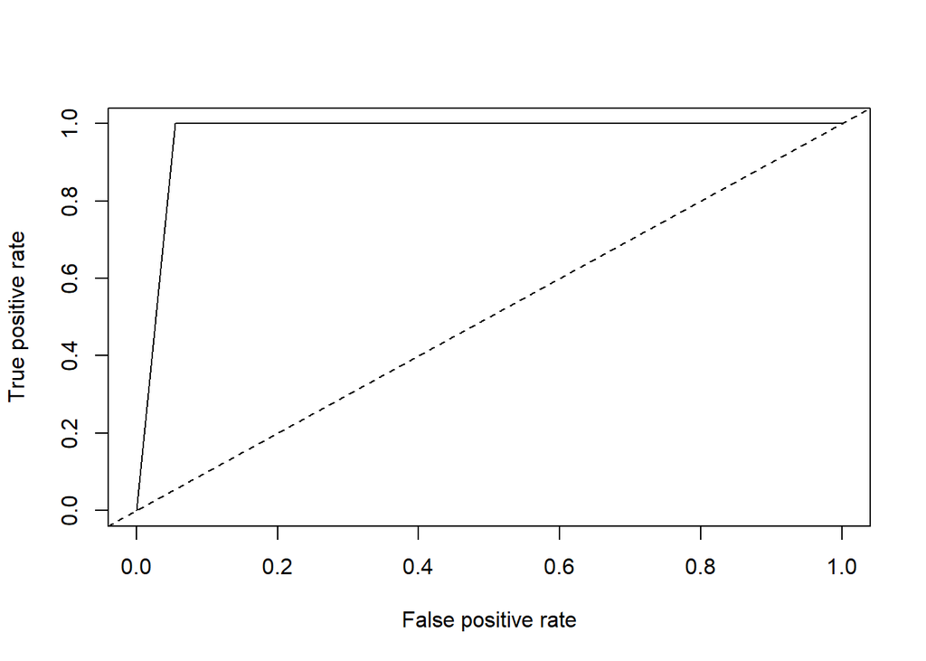

```r
## roc커브그리기 및 auc 산출

pred.logistic.roc<-prediction(as.numeric(pred1$grade),as.numeric(test[,1]))
plot(performance(pred.logistic.roc,"tpr","fpr"))
abline(a=0,b=1,lty=2,col="black")
```

```r
performance(pred.logistic.roc,"auc")@y.values
```

```
## [[1]]
## [1] 0.9726027
```

prediction 함수와 performance 함수로 값을 구하여 plot 함수로 ROC 커브를 그렸으며, AUC 값은 y.values 값으로 확인한 결과 0.9726 으로 나타났다.

## 의사결정나무

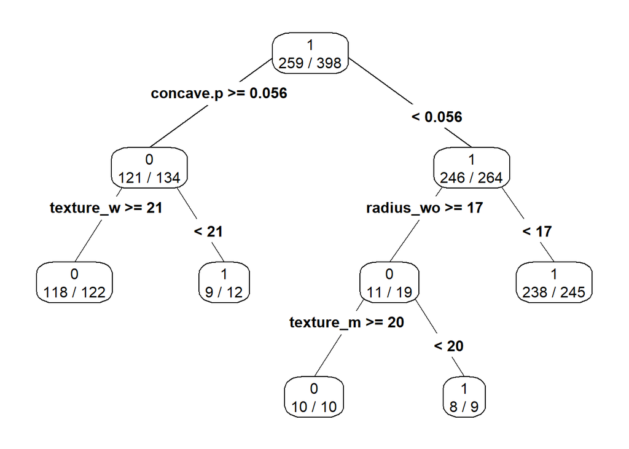

```r
## 의사결정나무

dt.model <- rpart(diagnosis~.,
                  method="class",
                  data=train,
                  control = rpart.control(maxdepth=5,
                                          minsplit=15))
prp(dt.model,type=4,extra =2)
```

앞서 분할한 데이터의 train 데이터로 의사결정나무 모델을 만들어보았다. 총 398개의 관측치 중 259개의 관측치를 1로 분류하였으며 concave.p < 0.056 인 264개의 노드중 246개가 1로 분류되었음을 의미한다.

```r
dt.model$cptable
```

```
##           CP nsplit rel error    xerror       xstd
## 1 0.77697842      0 1.0000000 1.0000000 0.06842282
## 2 0.04316547      1 0.2230216 0.3525180 0.04715790
## 3 0.03597122      2 0.1798561 0.2661871 0.04167716
## 4 0.01000000      4 0.1079137 0.2446043 0.04011750
```

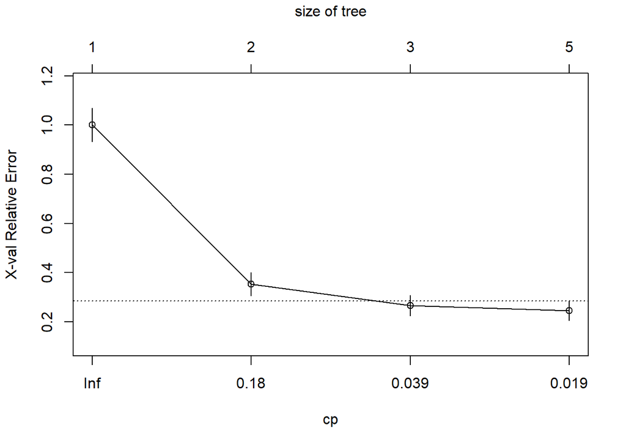

```r
opt<-which.min(dt.model$cptable[,"xerror"])
cp <-dt.model$cptable[opt,"CP"]
pr.c<-prune(dt.model,cp=cp)
plotcp(dt.model)
```

cptable 인자를 통해서 교차타당성 오차를 제공하여 의사결정나무 모델의 가지치기, 트리의 최대 크기조절에 사용한다. nsplit은 분할 횟수, xerror 는 해당 CP 에서 cross validation했을 때 오류율, xstd는 해당 CP 에서 cross validation 했을 때 편차를 나타낸다. cpatable 에서 xerror 가 가장 낮은 split 개수를 선택한다. 위 결과를 확인했을 때 **xerro가 가장 낮을때는 nsplit은 4** 이며, 앞선 모형의 그래프를 봤을 대 의사결정나무 모델이 분할을 4번까지 한다고 할 수 있다.

```r
pred.model<-predict(dt.model,test[,-1],type="class")
confusionMatrix(data=pred.model, reference = test[,1], positive='1')
```

```
## Confusion Matrix and Statistics
##
##           Reference
## Prediction  0  1
##          0 61  3
##          1 12 95
##
##                Accuracy : 0.9123
##                  95% CI : (0.8594, 0.9501)
##     No Information Rate : 0.5731
##     P-Value [Acc > NIR] : < 2e-16
##
##                   Kappa : 0.8179
##
##  Mcnemar's Test P-Value : 0.03887
##
##             Sensitivity : 0.9694
##             Specificity : 0.8356
##          Pos Pred Value : 0.8879
##          Neg Pred Value : 0.9531
##              Prevalence : 0.5731
##          Detection Rate : 0.5556
##    Detection Prevalence : 0.6257
##       Balanced Accuracy : 0.9025
##
##        'Positive' Class : 1
##
```

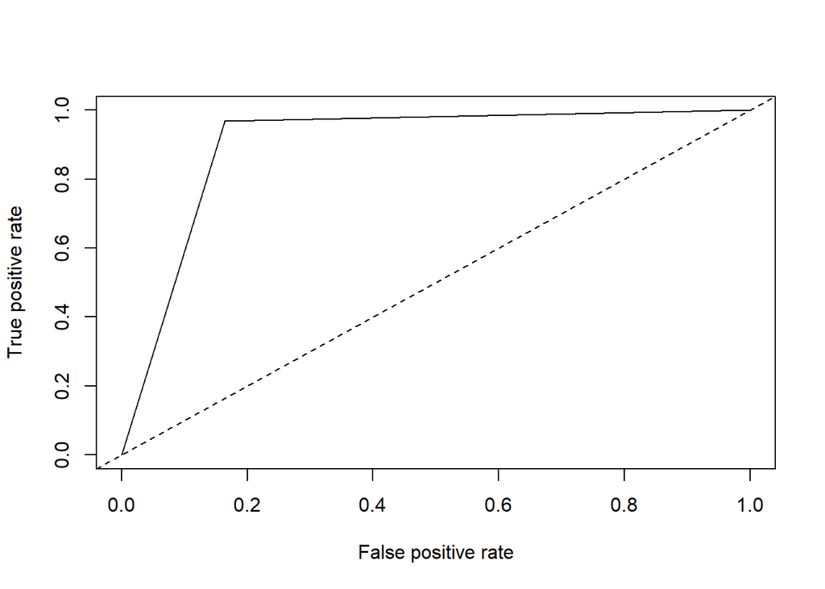

```r
## ROC 커브 그리기 및 AUC 산출

pred.model.roc<- prediction(as.numeric(pred.model),as.numeric(test[,1]))
plot(performance(pred.model.roc,"tpr","fpr"))
abline(a=0,b=1,lty=2, col="black")
```

```r
performance(pred.model.roc,"auc")@y.values
```

```
## [[1]]
## [1] 0.9025021
```

정분류율(Accuracy)은 0.9123이며 민감도 (Sensitivity)는 0.96이다. 특이도(Specificity)는 0.83이다.

## 앙상블(ensemble)기법

```r
# bagging 함수를 활용하여 bagging 분석 실시

bag_model <- bagging(diagnosis~.,
                     data = train,
                     mfinal=15)
names(bag_model)
```

```
## [1] "formula"    "trees"      "votes"      "prob"       "class"
## [6] "samples"    "importance" "terms"      "call"
```

```r
bag_model$importance #importance는 변수의 상대적인 중요도를 나타내며 지니지수의 gain을 고려한 축도
```

```
##               area_mean                 area_se              area_worst
##               0.9617215               0.0000000               0.8002994
##        compactness_mean          compactness_se       compactness_worst
##               0.0000000               0.5280380               0.0000000
##     concave.points_mean       concave.points_se    concave.points_worst
##              28.6515127               0.0000000              25.8479712
##          concavity_mean            concavity_se         concavity_worst
##               0.6531324               0.6460184               1.2906185
##  fractal_dimension_mean    fractal_dimension_se fractal_dimension_worst
##               0.0000000               0.0000000               0.0000000
##          perimeter_mean            perimeter_se         perimeter_worst
##               0.8214967               0.0000000              34.1324328
##             radius_mean               radius_se            radius_worst
##               0.7417856               0.0000000               1.4206124
##         smoothness_mean           smoothness_se        smoothness_worst
##               0.0000000               0.0000000               0.0000000
##           symmetry_mean             symmetry_se          symmetry_worst
##               0.0000000               0.0000000               0.0000000
##            texture_mean              texture_se           texture_worst
##               0.2667576               0.0000000               3.2376027
```

names 함수를 통해 bagging 함수로 생성된 결과들에 어떤 것들이 있는지 확인이 가능하다.  
importance 인자에서 변수의 상대적 중요도를 봤을때  
**perimeter_worst, concave.points_mean, concave.points_worst** 순서로 변수 중요도가 크다는 것을 파악할 수 있다.

```r
# 예측을 통한 정분류율 확인
pred.bmd <-predict(bag_model,test,type="class")
confusionMatrix(data = as.factor(pred.bmd$class), # class 열을 factor로 변환하여 test의 열과 맞춤
                reference = test$diagnosis,
                positive='1')
```

```
## Confusion Matrix and Statistics
##
##           Reference
## Prediction  0  1
##          0 69  4
##          1  4 94
##
##                Accuracy : 0.9532
##                  95% CI : (0.9099, 0.9796)
##     No Information Rate : 0.5731
##     P-Value [Acc > NIR] : <2e-16
##
##                   Kappa : 0.9044
##
##  Mcnemar's Test P-Value : 1
##
##             Sensitivity : 0.9592
##             Specificity : 0.9452
##          Pos Pred Value : 0.9592
##          Neg Pred Value : 0.9452
##              Prevalence : 0.5731
##          Detection Rate : 0.5497
##    Detection Prevalence : 0.5731
##       Balanced Accuracy : 0.9522
##
##        'Positive' Class : 1
##
```

정분류율(Accuracy)은 0.9532이며 민감도 (Sensitivity)는 0.95이다. 특이도(Specificity)는 0.94이다.

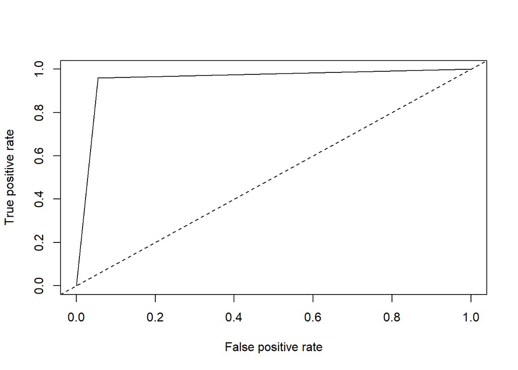

```r
#ROC 커브 그리기 및 AUC 산출

pred.bmd.roc <- prediction(as.numeric(pred.bmd$class),as.numeric(test[,1]))
plot(performance(pred.bmd.roc,"tpr","fpr"))
abline(a=0,b=1,lty=2,col="black")
```

```r
performance(pred.bmd.roc,"auc")@y.values
```

```
## [[1]]
## [1] 0.9521946
```

prediction 함수와 performance 함수로 값을 구하여 plot 함수로 ROC 커브를 그렸으며, AUC 값은 y.values 값으로 확인한 결과 0.9521 으로 나타났다.

## 랜덤 포레스트 (RandomForest)

```r
# randomForest 함수를 활용하여 RandomForest 분석 실시

rf.model <-randomForest(diagnosis~.,
                        data=train,
                        ntree=50,          #나무 50개 사용
                        mtry=sqrt(20),     #사용할 변수의 개수
                        importance=T)      #변수중요도 결과를 확인
rf.model
```

```
##
## Call:
##  randomForest(formula = diagnosis ~ ., data = train, ntree = 50,      mtry = sqrt(20), importance = T)
##                Type of random forest: classification
##                      Number of trees: 50
## No. of variables tried at each split: 4
##
##         OOB estimate of  error rate: 4.77%
## Confusion matrix:
##     0   1 class.error
## 0 126  13  0.09352518
## 1   6 253  0.02316602
```

```r
names(rf.model)
```

```
##  [1] "call"            "type"            "predicted"       "err.rate"
##  [5] "confusion"       "votes"           "oob.times"       "classes"
##  [9] "importance"      "importanceSD"    "localImportance" "proximity"
## [13] "ntree"           "mtry"            "forest"          "y"
## [17] "test"            "inbag"           "terms"
```

```r
rf.model$importance
```

```
##                                     0            1 MeanDecreaseAccuracy
## radius_mean              1.650642e-02 1.095599e-02         0.0130191996
## texture_mean             8.320622e-03 2.493441e-03         0.0045642692
## perimeter_mean           2.224558e-02 3.544449e-02         0.0310577283
## area_mean                2.643260e-02 2.422796e-02         0.0243820878
## smoothness_mean          8.708067e-03 2.848241e-03         0.0048288825
## compactness_mean        -2.968715e-04 5.096176e-04         0.0003379559
## concavity_mean           3.288434e-02 1.635501e-02         0.0223277710
## concave.points_mean      8.520500e-02 2.581815e-02         0.0458679559
## symmetry_mean            8.136397e-04 2.765371e-05         0.0003233742
## fractal_dimension_mean  -4.538426e-04 3.796920e-03         0.0023308988
## radius_se                1.030319e-02 1.470840e-02         0.0130269182
## texture_se               6.535948e-06 7.300774e-04         0.0004821464
## perimeter_se             1.111468e-02 1.976636e-02         0.0166460791
## area_se                  1.001040e-02 2.030240e-02         0.0169288071
## smoothness_se           -4.451781e-04 1.196039e-03         0.0006533470
## compactness_se           8.029307e-04 3.241811e-03         0.0023914094
## concavity_se             1.797344e-02 4.483145e-03         0.0094807222
## concave.points_se        7.504190e-04 1.973864e-03         0.0015214733
## symmetry_se             -1.163636e-03 2.337532e-03         0.0010007460
## fractal_dimension_se     1.531123e-03 4.530811e-04         0.0008675814
## radius_worst             2.320960e-02 6.695032e-02         0.0513435158
## texture_worst            1.378536e-02 6.015523e-03         0.0088905467
## perimeter_worst          5.029653e-02 4.475150e-02         0.0463235615
## area_worst               3.838040e-02 4.590980e-02         0.0433023782
## smoothness_worst         7.413403e-03 3.498634e-03         0.0048192843
## compactness_worst        4.465461e-03 1.294058e-02         0.0099228270
## concavity_worst          4.060345e-02 1.627929e-02         0.0250023830
## concave.points_worst     3.542552e-02 3.639777e-02         0.0360633769
## symmetry_worst           3.050887e-03 6.230675e-03         0.0051767778
## fractal_dimension_worst  3.399847e-03 2.988482e-03         0.0031690721
##                         MeanDecreaseGini
## radius_mean                   11.2101763
## texture_mean                   1.9895186
## perimeter_mean                 9.3040710
## area_mean                      9.0736252
## smoothness_mean                1.1666609
## compactness_mean               2.1127741
## concavity_mean                 4.1976885
## concave.points_mean           26.4693144
## symmetry_mean                  0.6094847
## fractal_dimension_mean         1.0104159
## radius_se                      3.7607261
## texture_se                     1.0677137
## perimeter_se                   7.3137889
## area_se                        5.7174328
## smoothness_se                  0.9043624
## compactness_se                 1.0166613
## concavity_se                   1.2471168
## concave.points_se              0.6282176
## symmetry_se                    1.5860763
## fractal_dimension_se           0.7612934
## radius_worst                  15.3480711
## texture_worst                  3.3445842
## perimeter_worst               19.1462933
## area_worst                    15.0967956
## smoothness_worst               2.5435791
## compactness_worst              3.4431081
## concavity_worst                3.3051571
## concave.points_worst          22.6945386
## symmetry_worst                 2.0723357
## fractal_dimension_worst        1.0019361
```

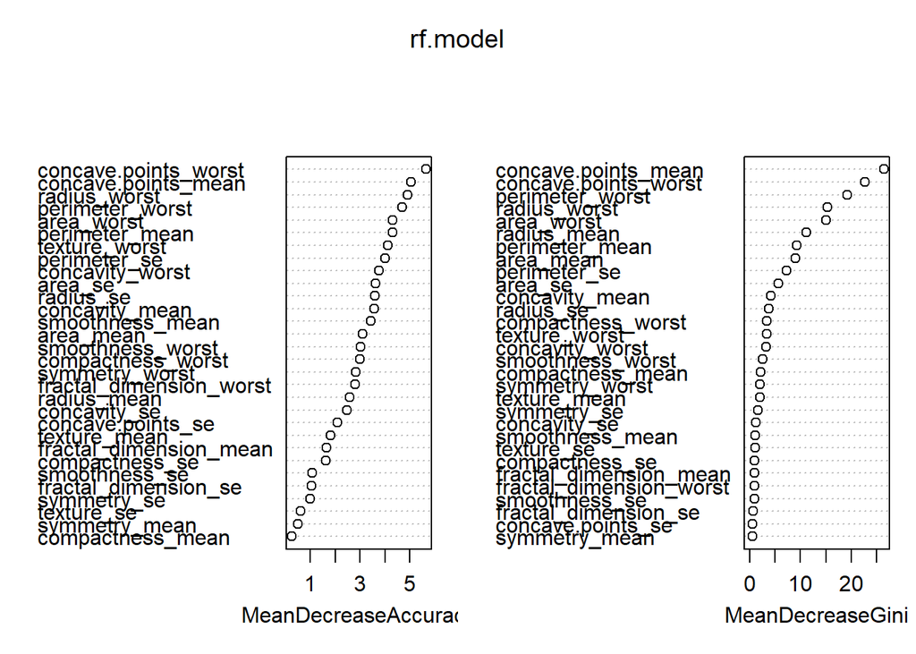

```r
varImpPlot(rf.model)
```

랜덤포레스트 분석 결과에서 “OOB estimate of error rate”의 값은 에러추정치로서 값이 낮을수록 분류모델의 성능이 좋다고 판단할 수 있다.  
**OOB의 값은 4.77%** 으로 에러추정치가 매우 낮은 것을 알 수 있다. Confusion matrix 에서 class.error값으로 분류 에러를 통해 모델 성능을 확인할 수 있다. class.error값이 매우 낮은것으로 나타났으므로 모델 성능이 좋다는 것을 알 수 있다.

varImpPlot 함수의 importance 인자 결과는 변수의 상대적 중요도 Mean DecreaseGini를 기준으로 봤을 때, **concave.points_mean, concave.points_worst, perimeter_worst** 순서로 변수 중요도가 크다는 것을 알 수 있다.

```r
# 예측을 통한 정분류율 확인

pred.rf<-predict(rf.model,test[,-1],type="class")
confusionMatrix(data= pred.rf, reference=test[,1], positive='1')
```

```
## Confusion Matrix and Statistics
##
##           Reference
## Prediction  0  1
##          0 70  3
##          1  3 95
##
##                Accuracy : 0.9649
##                  95% CI : (0.9252, 0.987)
##     No Information Rate : 0.5731
##     P-Value [Acc > NIR] : <2e-16
##
##                   Kappa : 0.9283
##
##  Mcnemar's Test P-Value : 1
##
##             Sensitivity : 0.9694
##             Specificity : 0.9589
##          Pos Pred Value : 0.9694
##          Neg Pred Value : 0.9589
##              Prevalence : 0.5731
##          Detection Rate : 0.5556
##    Detection Prevalence : 0.5731
##       Balanced Accuracy : 0.9641
##
##        'Positive' Class : 1
##
```

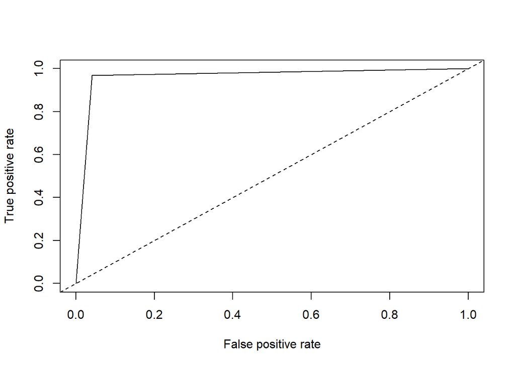

```r
pred.rf.roc<-prediction(as.numeric(pred.rf),as.numeric(test[,1]))
plot(performance(pred.rf.roc,"tpr","fpr"))
abline(a=0,b=1,lty=2,col="black")
```

정분류율(Accuracy)은 0.9649이며, 민감도 (Sensitivity)는 0.96이다. 특이도(Specificity)는 0.95이다.

## SVM 분석

```r
#tune.svm 함수를 활용하여 최적의 파라미터값 찾기기
tune.svm(diagnosis~.,
        data=df,
        gamma = 10^(-6:-1),  #  6*2 = 12개의 조합합
        cost = 10^(1:2))
```

```
##
## Parameter tuning of 'svm':
##
## - sampling method: 10-fold cross validation
##
## - best parameters:
##  gamma cost
##   0.01   10
##
## - best performance: 0.0193609
```

```r
#svm 함수를 활용하여 SVM 분석 실시
svm.model<-svm(diagnosis~.,
               data=train,
               kernel="sigmoid", #sigmoid 함수 사용
               gamma=0.01,
               cost=10)
summary(svm.model)
```

```
##
## Call:
## svm(formula = diagnosis ~ ., data = train, kernel = "sigmoid", gamma = 0.01,
##     cost = 10)
##
##
## Parameters:
##    SVM-Type:  C-classification
##  SVM-Kernel:  sigmoid
##        cost:  10
##      coef.0:  0
##
## Number of Support Vectors:  42
##
##  ( 20 22 )
##
##
## Number of Classes:  2
##
## Levels:
##  0 1
```

gamma는 0.01 cost는 10이 최적의 파라미터임을 확인할 수 있다.

```r
# 예측을 통한 정분류율 확인
pred.svm <- predict(svm.model,test,type="class")
confusionMatrix(data=pred.svm, reference=test[,1], positive='1')
```

```
## Confusion Matrix and Statistics
##
##           Reference
## Prediction  0  1
##          0 69  2
##          1  4 96
##
##                Accuracy : 0.9649
##                  95% CI : (0.9252, 0.987)
##     No Information Rate : 0.5731
##     P-Value [Acc > NIR] : <2e-16
##
##                   Kappa : 0.928
##
##  Mcnemar's Test P-Value : 0.6831
##
##             Sensitivity : 0.9796
##             Specificity : 0.9452
##          Pos Pred Value : 0.9600
##          Neg Pred Value : 0.9718
##              Prevalence : 0.5731
##          Detection Rate : 0.5614
##    Detection Prevalence : 0.5848
##       Balanced Accuracy : 0.9624
##
##        'Positive' Class : 1
##
```

정분류율(Accuracy)은 0.9649이며, 민감도 (Sensitivity)는 0.97이다. 특이도(Specificity)는 0.94이다.

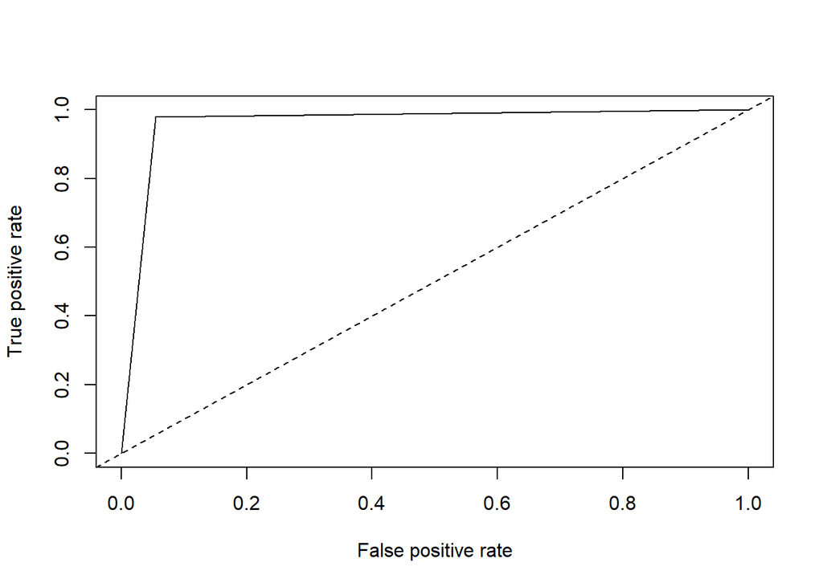

```r
#ROC 커브 그리기 및 AUC 산출
pred.svm.roc<-prediction(as.numeric(pred.svm),as.numeric(test[,1]))
plot(performance(pred.svm.roc,"tpr","fpr")) #ROC Curve 작성
abline(a=0,b=1,lty=2,col="black")
```

```r
performance(pred.svm.roc,"auc")@y.values
```

```
## [[1]]
## [1] 0.9623987
```

preediction 함수와 performance 함수로 값을 구하여 plot 함수로 ROC 커브를 그렸으며 AUC 값은 y.values 값으로 확인한 결과 0.9623으로 나타났다.